# Problems with model errors

15 April 2026

## Goals for today

- Understand how generalized least squares can be used when the errors are correlated
- Understand how weighted least squares can be used when the errors have nonconstant variance
- Understand how robust methods can be used when the errors are non-normal or when we have influential observations

## Concerns re: model assumptions

1. Adequacy of the model
2. Independence of errors
3. Non-constant variance
4. Normality of errors

## Possible options

1. Adequacy of the model \(\rightarrow\) possible change in structure
2. Independence of errors \(\rightarrow\) generalized least squares
3. Non-constant variance \(\rightarrow\) weighted least squares
4. Normality of errors \(\rightarrow\) robust methods, transformations

## Generalized least squares

Consider our general model where

\[ y_i = \beta_0 + \beta_1 x_{1,i} + \beta_2 x_{2,i} + \cdots + \beta_k x_{k,i} + e_i \\ e_i \sim \text{N}(0, \sigma^2) \]

which we can write more compactly as

\[ \mathbf{y} = \mathbf{X} \boldsymbol{\beta} + \mathbf{e} \\ \mathbf{e} \sim \text{MVN}(\mathbf{0}, \boldsymbol{\Sigma}) \]

What exactly is \(\boldsymbol{\Sigma}\)?

## An aside on multivariate normals

Consider a vector of random variables \(\mathbf{z}\)

The mean of \(\mathbf{z}\) is also a vector, but the variance of \(\mathbf{z}\) is a matrix

\[ \mathbf{z} \sim \text{MVN} \left( \boldsymbol{\mu}, \boldsymbol{\Sigma} \right) \\ \Downarrow \\ \mathbf{z} \sim \text{MVN} \left( \begin{bmatrix} \mu_1 \\ \mu_2 \\ \vdots \\ \mu_n \end{bmatrix}, \begin{bmatrix} \sigma^2_1 & \gamma_{12} & \cdots & \gamma_{1n} \\ \gamma_{21} & \sigma^2_2 & \cdots & \gamma_{2n} \\ \vdots & \vdots & \ddots & \vdots \\ \gamma_{n1} & \gamma_{n2} & \cdots & \sigma^2_n \end{bmatrix} \right) \]

## An aside on multivariate normals

More specifically for \(\boldsymbol{\Sigma}\)

- the diagonal contains the variances \(\sigma^2_i\)
- the off-diagonals are the covariances \(\gamma_{ij} = \gamma_{ji}\)

\[ \boldsymbol{\Sigma} = \begin{bmatrix} \sigma^2_1 & \gamma_{12} & \cdots & \gamma_{1n} \\ \gamma_{21} & \sigma^2_2 & \cdots & \gamma_{2n} \\ \vdots & \vdots & \ddots & \vdots \\ \gamma_{n1} & \gamma_{n2} & \cdots & \sigma^2_n \end{bmatrix} \]

## An aside on multivariate normals

One of our key assumptions in ordinary least squares is that the errors \(\mathbf{e}\) are *independent and identically distributed* (IID)

*Independent* means the covariances are all zero

\[ \boldsymbol{\Sigma} = \begin{bmatrix} \sigma^2_1 & 0 & \cdots & 0 \\ 0 & \sigma^2_2 & \cdots & 0 \\ \vdots & \vdots & \ddots & \vdots \\ 0 & 0 & \cdots & \sigma^2_n \end{bmatrix} \]

## An aside on multivariate normals

*Identically distributed* means the variances are all the same

\[ \boldsymbol{\Sigma} = \begin{bmatrix} \sigma^2 & 0 & \cdots & 0 \\ 0 & \sigma^2 & \cdots & 0 \\ \vdots & \vdots & \ddots & \vdots \\ 0 & 0 & \cdots & \sigma^2 \end{bmatrix} = \sigma^2 \begin{bmatrix} 1 & 0 & 0 & 0 \\ 0 & 1 & 0 & 0 \\ 0 & 0 & \ddots & 0 \\ 0 & 0 & 0 & 1 \end{bmatrix} = \sigma^2 \mathbf{I} \]

## Generalized least squares

In cases where the variances are not equal or the covariances are not zero, we can use *generalized least squares* (GLS)

\[ \boldsymbol{\Sigma} = \begin{bmatrix} \sigma^2_1 & \gamma_{12} & \cdots & \gamma_{1n} \\ \gamma_{21} & \sigma^2_2 & \cdots & \gamma_{2n} \\ \vdots & \vdots & \ddots & \vdots \\ \gamma_{n1} & \gamma_{n2} & \cdots & \sigma^2_n \end{bmatrix} \]

## Generalized least squares

Let’s begin by expressing \(\Sigma\) as a product of \(\sigma^2\) and a matrix \(\mathbf{C}\), such that

\[ \boldsymbol{\Sigma} = \sigma^2 \begin{bmatrix} c_{11} & c_{12} & \cdots & c_{1n} \\ c_{21} & c_{22} & \cdots & c_{21} \\ \vdots & \vdots & \ddots & \vdots \\ c_{n1} & c_{n2} & \cdots & c_{nn} \end{bmatrix} \]

## Generalized least squares

Next we will specify \(\mathbf{C}\) in terms of its [Cholesky decomposition](https://en.wikipedia.org/wiki/Cholesky_decomposition)

\[ \mathbf{C} = \mathbf{S} \mathbf{S} ^{\top} \]

where \(\mathbf{S}\) is a *lower triangular* matrix

\[ \mathbf{S} = \begin{bmatrix} s_{11} & 0 & \cdots & 0 \\ s_{21} & s_{22} & \cdots & 0 \\ \vdots & \vdots & \ddots & \vdots \\ s_{n1} & s_{n2} & \cdots & s_{nn} \end{bmatrix} \]

## Generalized least squares

You can think of the Cholesky decomposition as a square root transformation for matrices

Consider this example

```r
## symmetrical matrix
CC <- matrix(c(3,4,3,4,8,6,3,6,9), 3, 3)
CC
```

```
##      [,1] [,2] [,3]
## [1,]    3    4    3
## [2,]    4    8    6
## [3,]    3    6    9
```

## Generalized least squares

```r
## Choleshky decomposition; `chol()` returns t(S)
SS <- t(chol(CC))
round(SS, 2)
```

```
##      [,1] [,2] [,3]
## [1,] 1.73 0.00 0.00
## [2,] 2.31 1.63 0.00
## [3,] 1.73 1.22 2.12
```

```r
## reassemble Sigma
SS %*% t(SS)
```

```
##      [,1] [,2] [,3]
## [1,]    3    4    3
## [2,]    4    8    6
## [3,]    3    6    9
```

## Generalized least squares

We can now use our decomposition matrix \(\mathbf{S}\) to transform our standard regression model, such that

\[ \begin{aligned} \mathbf{y} &= \mathbf{X} \boldsymbol{\beta} + \mathbf{e} \\ &~ ~ ~ ~ ~ \Downarrow\\ \mathbf{S}^{-1} \mathbf{y} &= \mathbf{S}^{-1} \mathbf{X} \boldsymbol{\beta} + \mathbf{S}^{-1} \mathbf{e} \\ \mathbf{y}' &= \mathbf{X}' \boldsymbol{\beta} + \mathbf{e}' \end{aligned} \] and hence

\[ \text{Var}(\mathbf{e}') = \text{Var}(\mathbf{S}^{-1} \mathbf{e}) \]

## Generalized least squares

We can now solve for \(\text{Var}(\mathbf{e}')\)

\[ \begin{aligned} \text{Var}(\mathbf{e}') &= \text{Var}(\mathbf{S}^{-1} \mathbf{e}) \\ &= \mathbf{S}^{-1} \text{Var}( \mathbf{e}) (\mathbf{S}^{-1})^{\top} \\ &= \mathbf{S}^{-1} \boldsymbol{\Sigma} (\mathbf{S}^{-1})^{\top} \\ &= \mathbf{S}^{-1} [\sigma \mathbf{C}] (\mathbf{S}^{-1})^{\top} \\ &= \mathbf{S}^{-1} [\sigma \mathbf{S} \mathbf{S}^{\top}] (\mathbf{S}^{-1})^{\top} \\ &= \sigma \mathbf{I} \end{aligned} \]

and the errors \(\mathbf{e}'\) are now IID!

## Generalized least squares

The \(SSE\) is then given by

\[ \begin{aligned} \mathbf{e'}^{\top} \mathbf{e'} &= (\mathbf{y'} - \mathbf{X'} \hat{\boldsymbol{\beta}})^{\top} (\mathbf{y'} - \mathbf{X'} \hat{\boldsymbol{\beta}}) \\ &= (\mathbf{S}^{-1}\mathbf{y} - \mathbf{S}^{-1}\mathbf{X} \hat{\boldsymbol{\beta}})^{\top} (\mathbf{S}^{-1}\mathbf{y} - \mathbf{S}^{-1}\mathbf{X} \hat{\boldsymbol{\beta}}) \\ &= (\mathbf{y} - \mathbf{X} \hat{\boldsymbol{\beta}})^{\top} {\mathbf{S}^{-1}}^{\top} \mathbf{S}^{-1} (\mathbf{y} - \mathbf{X} \hat{\boldsymbol{\beta}}) \\ &= (\mathbf{y} - \mathbf{X} \hat{\boldsymbol{\beta}})^{\top} \mathbf{C}^{-1} (\mathbf{y} - \mathbf{X} \hat{\boldsymbol{\beta}}) \end{aligned} \]

## Generalized least squares

We can minimize the SSE to find \(\hat{\boldsymbol{\beta}}\)

\[ \begin{aligned} \hat{\boldsymbol{\beta}} &= \min ~ (\mathbf{y} - \mathbf{X} \boldsymbol{\beta})^{\top} \mathbf{C}^{-1} (\mathbf{y} - \mathbf{X} \boldsymbol{\beta}) \\ &= (\mathbf{X}^{\top} \mathbf{C}^{-1} \mathbf{X}) \mathbf{X}^{\top} \mathbf{C}^{-1} \mathbf{y} \end{aligned} \]

and from this find that

\[ \text{Var}(\hat{\boldsymbol{\beta}}) = \sigma^2 (\mathbf{X}^{\top} \mathbf{C}^{-1} \mathbf{X})^{-1} \]

## Generalized least squares

This all looks great, but typcially we do not know \(\mathbf{C}\)

Let’s think about situations where the \(e_i\) are not independent

- time series
- spatial data
- grouped (blocked) data

## Autcorrelated data

When modeling data that are collected over time, it’s common that the predictor variable(s) will not account for all of the temporal structure in the data

## Autcorrelated data

One option is to explicitly model the errors as an *autoregressive process* where (replacing \(i\) with \(t\))

\[ e_t = \phi e_{t-1} + \delta_t \\ \delta_t \sim \text{N}(0, \tau^2) \\ \Downarrow \\ e_t \sim \text{N}(\phi e_{t-1}, \tau^2) \]

To do this in **R** we need additional packages not included with the base installation (eg, **nlme**)

## Weighted least squares

Sometimes the errors are *independent **but not** identically distributed* and the covariance matrix is

\[ \boldsymbol{\Sigma} = \begin{bmatrix} \sigma^2_1 & 0 & \cdots & 0 \\ 0 & \sigma^2_2 & \cdots & 0 \\ \vdots & \vdots & \ddots & \vdots \\ 0 & 0 & \cdots & \sigma^2_n \end{bmatrix} \]

## Weighted least squares

Sometimes the errors are *independent **but not** identically distributed* and the covariance matrix is

\[ \boldsymbol{\Sigma} = \begin{bmatrix} \sigma^2_1 & 0 & \cdots & 0 \\ 0 & \sigma^2_2 & \cdots & 0 \\ \vdots & \vdots & \ddots & \vdots \\ 0 & 0 & \cdots & \sigma^2_n \end{bmatrix} \]

In these cases we can use a subset of generalized least squares called *weighted least squares*

## Weighted least squares

Similar to GLS, we can express \(\boldsymbol{\Sigma}\) in terms of \(\sigma\) and a matrix \(\mathbf{C}\) with non-diagonal elements equal to 0

\[ \boldsymbol{\Sigma} = \sigma^2 \begin{bmatrix} c_1 & 0 & 0 & 0 \\ 0 & c_2 & 0 & 0 \\ 0 & 0 & \ddots & 0 \\ 0 & 0 & 0 & c_n \end{bmatrix} = \sigma^2 \mathbf{C} \]

## Weighted least squares

We saw earlier that we could fit a GLS model with OLS if we could express the variance in the transformed errors as a function of the Cholesky decomposition of \(\mathbf{C} = \mathbf{S} \mathbf{S}^{\top}\), where

\[ \begin{aligned} \text{Var}(\mathbf{e}') &= \text{Var}(\mathbf{S}^{-1} \mathbf{e}) \\ &= \sigma \mathbf{I} \end{aligned} \]

This suggest a *weighting* of \(\mathbf{e}\) proportional to \(\mathbf{S}^{-1}\)

## Weighted least squares

Let’s define our variance multiplier \(\mathbf{S}^{-1}\) as

\[ \mathbf{S}^{-1} = \begin{bmatrix} \tfrac{1}{\sqrt{w_1}} & 0 & 0 & 0 \\ 0 & \tfrac{1}{\sqrt{w_2}} & 0 & 0 \\ 0 & 0 & \ddots & 0 \\ 0 & 0 & 0 & \tfrac{1}{\sqrt{w_n}} \end{bmatrix} \]

## Weighted least squares

From this we can define a weights matrix\(\mathbf{W}\) as

\[ \begin{aligned} \mathbf{W} &= \mathbf{S} \mathbf{S}^{\top} \\ &= \begin{bmatrix} w_1 & 0 & 0 & 0 \\ 0 & w_2 & 0 & 0 \\ 0 & 0 & \ddots & 0 \\ 0 & 0 & 0 & w_3 \end{bmatrix} \end{aligned} \]

How do we choose the weights?

## Weighted least squares

### Errors proportional to the predictor

In general, the weights \(w_i\) should reflect differences in the variance of the errors \(\epsilon_i\)

In many ecological applications, we find that the variance is proportional to a predictor

\[ \text{Var}(\epsilon_i) = x_i \sigma^2 \]

This suggests \(w_i = \frac{1}{x_i}\)

## Weighted least squares

### Observations are averages

It’s not uncommon that the observations \(y_i\) are actually averages of several pieces of raw data

In that case

\[ \text{Var}(\epsilon_i) = \frac{\sigma^2}{n_i} \]

This suggests \(w_i = n_i\)

## Weighted least squares

### Observations are sums

Similarly, the observations \(y_i\) might be sums of several pieces of raw data

In that case

\[ \text{Var}(\epsilon_i) =n_i \sigma^2 \]

This suggests \(w_i = \frac{1}{n_i}\)

## Robust regression

We saw in the last lecture that non-normal errors & unusual observations can affect model fits

## Robust regression

We saw in the last lecture that non-normal errors & unusual observations can affect model fits

In these case we can use so-called *robust regression*

## Robust regression

### M-estimation

Recall that our goal in ordinary least squares is to minimize the error sum-of-squares \((SSE)\)

\[ SSE = \sum^n_{i = 1} (y_i - \boldsymbol{\beta} \mathbf{x}_i)^2 \]

The objective function is the squared differences between the data and their estimates

## Robust regression

### M-estimation

An alternative is to minimize a different function

\[ \begin{aligned} SSE &= \sum^n_{i = 1} (y_i - \boldsymbol{\beta} \mathbf{x}_i)^2 \\ &\Downarrow \\ SSE &= \sum^n_{i = 1} f(z) \end{aligned} \]

## Robust regression

### M-estimation

One possibility for \(f(z)\) is the *least absolute deviation* (LAD)

\[ SSE = \sum^n_{i = 1} \left| y_i - \boldsymbol{\beta} \mathbf{x}_i \right| \\ \]

## Robust regression

### M-estimation

Another possibility is *Huber’s method* where

\[ SSE = \sum^n_{i = 1} f(z) \\ ~ \\ f(z) = \left\{ \begin{matrix} \frac{z^2}{2} & \text{if} ~ \left| z \right| \leq c \\ c \left| z \right| - \frac{c^2}{2} & \text{otherwise} \end{matrix} \right. \]

and \(c = \hat{\sigma} \propto \text{Median}(\left| \hat{\epsilon} \right|)\)

## Robust regression

### M-estimation via Huber’s method

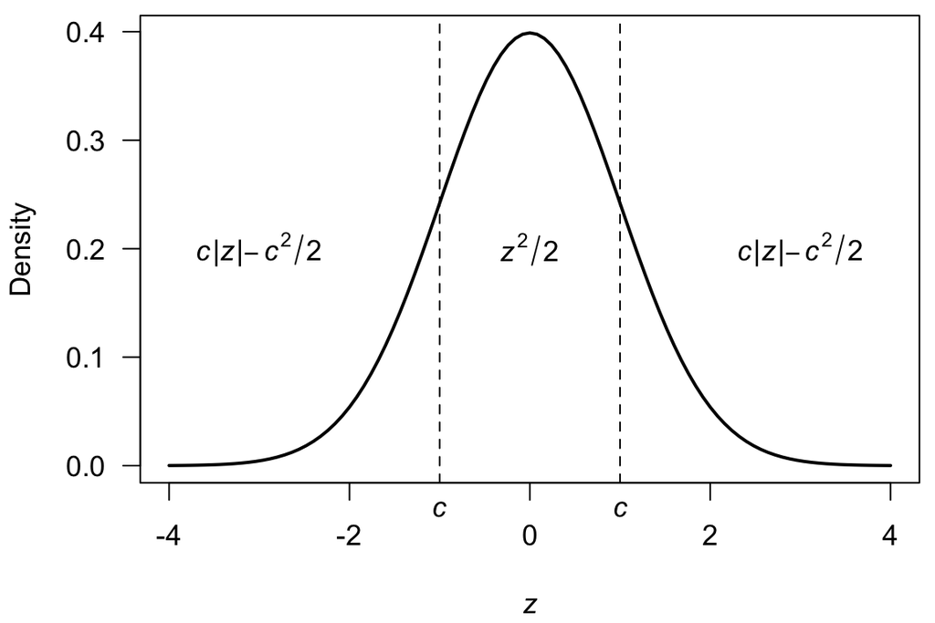

## Robust regression

### M-estimation via Huber’s method

Note the following:

- M-estimation does not address points with large leverage
- it says nothing about which predictors to include
- it says nothing about which transformations to make

## Robust regression

### Least trimmed squares

M-estimation will fail if the large errors are numerous and extreme in value

*Least trimmed squares* (LTS) is a resistant regression method that deals well with this situation

## Robust regression

### Least trimmed squares

LTS minimizes the sum of squares of the \(q\) smallest residuals

\[ SSE = \sum^n_{i = 1} e^2_{i} ~ \rightarrow ~ SSE_q = \sum^q_{i = 1} e^2_{(i)} \]

and \((i)\) indicates the residuals are sorted in ascending order

The default is \(q = \lfloor n/2 \rfloor + \lfloor (k + 1) / 2 \rfloor\)

where \(\lfloor \cdot \rfloor\) is the floor function

## Robust regression

### Least trimmed squares

In practice, we can easily fit LTS models in **R** with `MASS::ltsreg()` but it does not provide estimates of the parameter uncertainty

We can, however, estimate it via bootstrapping

## Robust regression

### Least trimmed squares bootstrapping procedure

1. Fit your model to the data
2. Calculate \(\mathbf{e} = \mathbf{y} - \mathbf{X} \hat{\boldsymbol{\beta}}\)
3. Do the following *many* times:
   - Generate \(\mathbf{e}^*\) by sampling *with replacement* from \(\mathbf{e}\)
   - Calculate \(\mathbf{y}^*\) = \(\mathbf{X} \hat{\boldsymbol{\beta}} + \mathbf{e}^*\)
   - Estimate \(\hat{\boldsymbol{\beta}}^*\) from \(\mathbf{X}\) & \(\mathbf{y}^*\))
4. Select the \(\tfrac{\alpha}{2}\) and \((1 - \tfrac{\alpha}{2})\) percentiles from the saved \(\hat{\boldsymbol{\beta}}^*\)

## Summary

1. Robust methods protect against long-tailed errors, but they cannot overcome problems with the choice of model and its variance structure

## Summary

1. Robust methods protect against long-tailed errors, but they cannot overcome problems with the choice of model and its variance structure
2. Robust methods give \(\hat{\boldsymbol{\beta}}\) without the associated inferential methods, but we can use bootstrapping to overcome this

## Summary

1. Robust methods protect against long-tailed errors, but they cannot overcome problems with the choice of model and its variance structure
2. Robust methods give \(\hat{\boldsymbol{\beta}}\) without the associated inferential methods, but we can use bootstrapping to overcome this
3. Robust methods can be used to confirm least squares estimates; it’s worth checking if they deviate from one another

## Summary

1. Robust methods protect against long-tailed errors, but they cannot overcome problems with the choice of model and its variance structure
2. Robust methods give \(\hat{\boldsymbol{\beta}}\) without the associated inferential methods, but we can use bootstrapping to overcome this
3. Robust methods can be used to confirm least squares estimates; it’s worth checking if they deviate from one another
4. Robust methods are useful when data need to be fit automatically without human intervention, which is rare in ecology